# Homework 2

Jenna Thomas

2023-05-22

Apologies for phoning this one in, I’ve had a number of interviews this week and just didn’t have time to dedicate to this.

# 1 Data Visualisation - Exploration

Now that you’ve demonstrated your software is setup, and you have the basics of data manipulation, the goal of this assignment is to practice transforming, visualising, and exploring data.

# 2 Mass shootings in the US

In July 2012, in the aftermath of a mass shooting in a movie theater in Aurora, Colorado, [Mother Jones](https://www.motherjones.com/politics/2012/07/mass-shootings-map/) published a report on mass shootings in the United States since 1982. Importantly, they provided the underlying data set as [an open-source database](https://www.motherjones.com/politics/2012/12/mass-shootings-mother-jones-full-data/) for anyone interested in studying and understanding this criminal behavior.

## 2.1 Obtain the data

```
## Rows: 144
## Columns: 24
## $ case                             <chr> "New Mexico neighborhood shooting", "…
## $ location...2                     <chr> "Farmington, New Mexico", "Allen, Tex…
## $ date                             <chr> "5/15/23", "5/6/23", "4/10/23", "3/27…
## $ summary                          <chr> "Beau Wilson, 18, opened fire on the …
## $ fatalities                       <dbl> 3, 8, 5, 6, 3, 7, 11, 6, 5, 3, 5, 3, …
## $ injured                          <dbl> 6, 7, 8, 6, 5, 1, 10, 6, 25, 2, 2, 2,…
## $ total_victims                    <dbl> 9, 15, 13, 12, 8, 8, 21, 12, 30, 5, 7…
## $ location...8                     <chr> "Other", "Other", "workplace", "Schoo…
## $ age_of_shooter                   <chr> "18", "33", "25", "28", "43", "67", "…
## $ prior_signs_mental_health_issues <chr> "-", "yes", "yes", "-", "-", "-", "ye…
## $ mental_health_details            <chr> "-", "Reportedly had a history of men…
## $ weapons_obtained_legally         <chr> "yes", "yes", "yes", "yes", "yes", "-…
## $ where_obtained                   <chr> "-", "-", "gun dealership in Louisvil…
## $ weapon_type                      <chr> "semiautiomatic rifle; semiautomatic …
## $ weapon_details                   <chr> "AR-15-style rifle", "AR-15-style rif…
## $ race                             <chr> "-", "Latino", "White", "White", "Bla…
## $ gender                           <chr> "M", "M", "M", "F (\"identifies as tr…
## $ sources                          <chr> "https://www.cbsnews.com/news/farming…
## $ mental_health_sources            <chr> "-", "-", "-", "-", "-", "-", "https:…
## $ sources_additional_age           <chr> "-", "-", "-", "-", "-", "-", "-", "-…
## $ latitude                         <chr> "-", "-", "-", "-", "-", "-", "-", "-…
## $ longitude                        <chr> "-", "-", "-", "-", "-", "-", "-", "-…
## $ type                             <chr> "mass", "Mass", "Mass", "Mass", "Mass…
## $ year                             <dbl> 2023, 2023, 2023, 2023, 2023, 2023, 2…
```

| column(variable) | description |
| --- | --- |
| case | short name of incident |
| year, month, day | year, month, day in which the shooting occurred |
| location | city and state where the shooting occcurred |
| summary | brief description of the incident |
| fatalities | Number of fatalities in the incident, excluding the shooter |
| injured | Number of injured, non-fatal victims in the incident, excluding the shooter |
| total_victims | number of total victims in the incident, excluding the shooter |
| location_type | generic location in which the shooting took place |
| male | logical value, indicating whether the shooter was male |
| age_of_shooter | age of the shooter when the incident occured |
| race | race of the shooter |
| prior_mental_illness | did the shooter show evidence of mental illness prior to the incident? |

## 2.2 Explore the data

### 2.2.1 Specific questions

- Generate a data frame that summarizes the number of mass shootings per year.

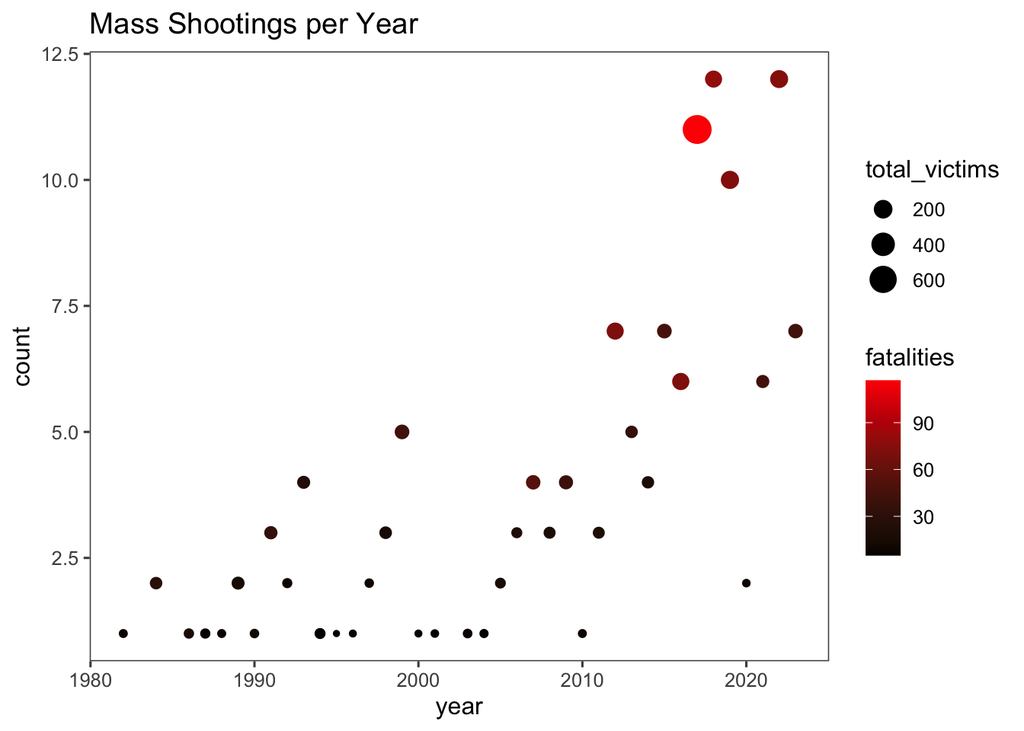

```r
# summarise the number of mass shootings per year
df <- mass_shootings %>%
  group_by(year) %>%
  summarise(fatalities = sum(fatalities), injured = sum(injured), total_victims = sum(total_victims),count = n())

# visualize summary data
df %>%
  ggplot(aes(x = year, y = count, size = total_victims, color = fatalities)) +
  geom_point() +
  scale_color_gradient(low = "black", high = "red") +
  ggtitle("Mass Shootings per Year") +
  ggthemes::theme_few()
```

```r
rm(df)
```

- Generate a bar chart that identifies the number of mass shooters associated with each race category. The bars should be sorted from highest to lowest and each bar should show its number.

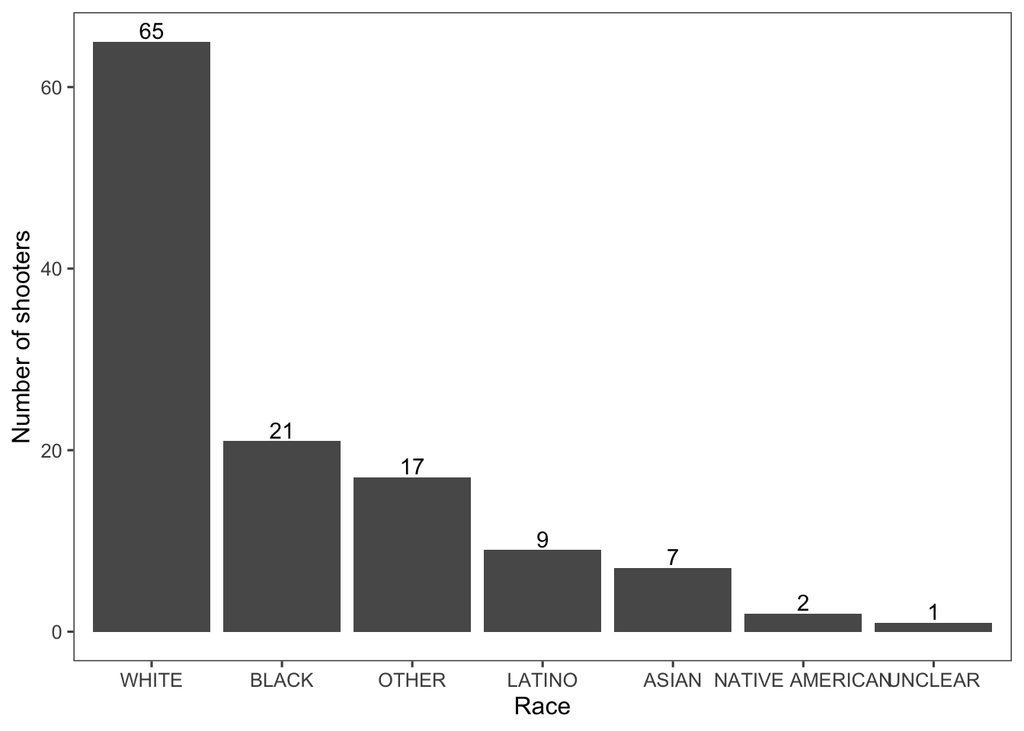

```r
mass_shootings %>%
  # consolidate variables
  mutate(race = replace(race, race == "-","Other")) %>%
  filter(type == "Mass") %>%
  # make case insensitive before grouping
  group_by(toupper(race)) %>%
  summarise(n()) %>%
  # clean names
  rename(race = 'toupper(race)', shooters = 'n()') %>%
  ggplot(aes(x = reorder(race,-shooters), y = shooters)) +
  geom_bar(stat = "identity") +
  geom_text(aes(label = shooters), vjust = -0.2) +
  xlab("Race") +
  ylab("Number of shooters") +
  ggthemes::theme_few()
```

- Generate a boxplot visualizing the number of total victims, by type of location.

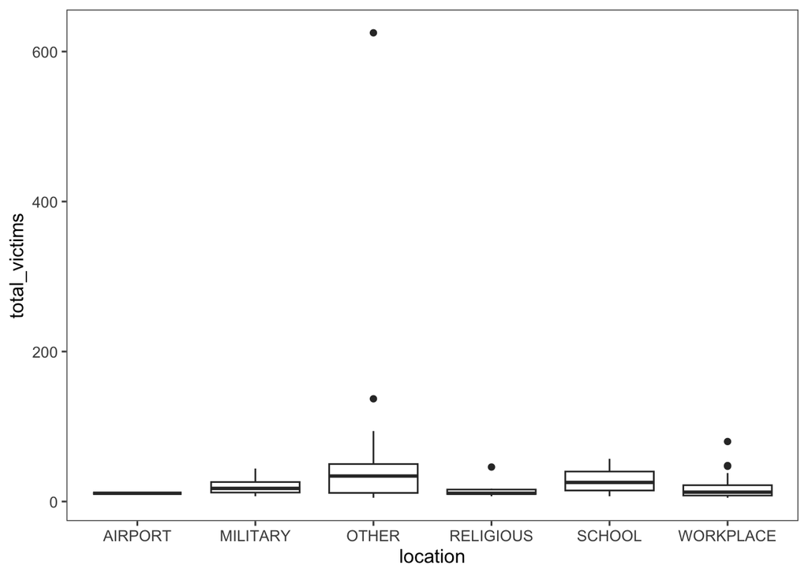

```r
mass_shootings %>%
  # clean names [though I think there must be a better way]
  mutate_all(~gsub("\n","",.)) %>%
  # make case insensitive for consolidation
  group_by(location = toupper(location...8),year) %>%
  # idk why it wasn't working, total_victim class was parsed as numeric originally
  summarise(shootings = n(), total_victims = sum(as.numeric(total_victims))) %>%
  ggplot(aes(x = location, y = total_victims)) +
  geom_boxplot() +
  ggthemes::theme_few()
```

- Redraw the same plot, but remove the Las Vegas Strip massacre from the dataset.

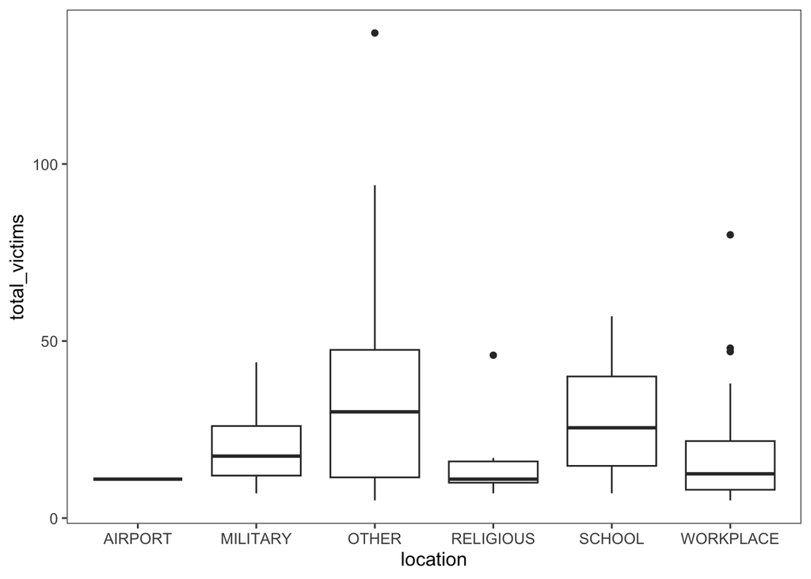

```r
mass_shootings %>%
  # filter out LV
  filter(!grepl("Las Vegas Strip",case)) %>%
  # clean names [though I think there must be a better way]
  mutate_all(~gsub("\n","",.)) %>%
  # make case insensitive for consolidation
  group_by(location = toupper(location...8),year) %>%
  # idk why it wasn't working, total_victim class was parsed as numeric originally
  summarise(shootings = n(), total_victims = sum(as.numeric(total_victims))) %>%
  ggplot(aes(x = location, y = total_victims)) +
  geom_boxplot() +
  ggthemes::theme_few()
```

### 2.2.2 More open-ended questions

Address the following questions. Generate appropriate figures/tables to support your conclusions.

- How many white males with prior signs of mental illness initiated a mass shooting after 2000?

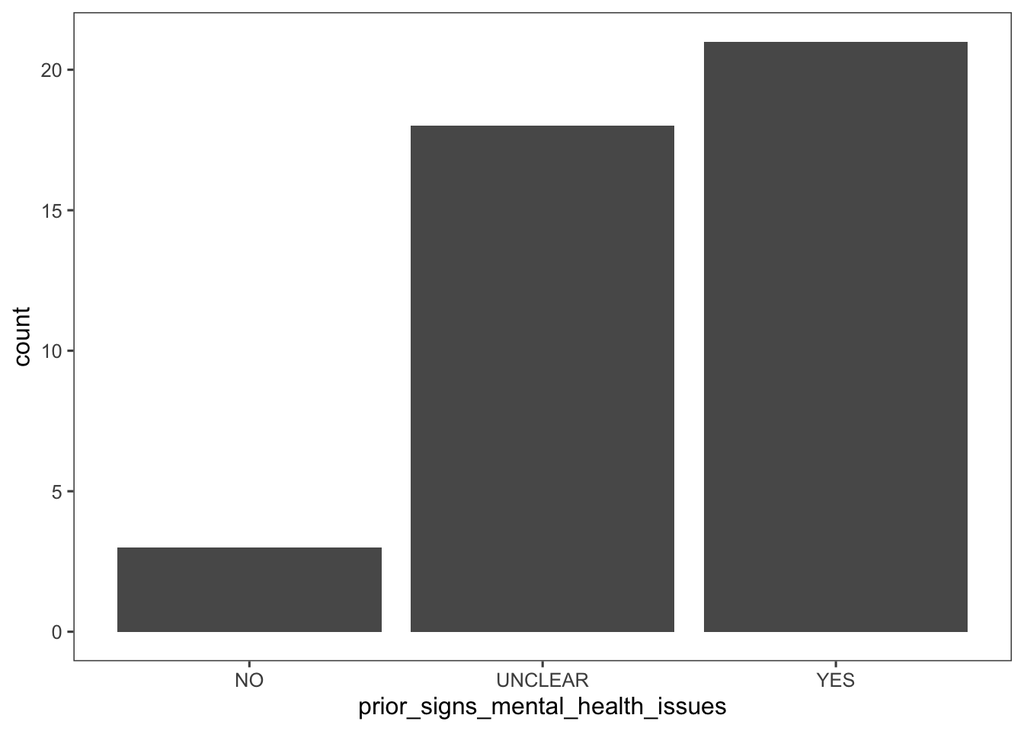

```r
mass_shootings %>%
  # clean up values
  mutate(race = toupper(replace(race, race == "-","Other")),
         prior_signs_mental_health_issues = toupper(replace(prior_signs_mental_health_issues,
                                                            prior_signs_mental_health_issues %in% c("-","TBD"),"Unclear"))) %>%
  filter(year > 2000) %>%
  filter(race == "WHITE") %>%
  filter(type == "Mass") %>%
  # remove non-males
  filter(!grepl("F",gender)) %>%
  group_by(year,prior_signs_mental_health_issues) %>%
  summarise(count = n()) %>%
  ggplot(aes(y = count, x = prior_signs_mental_health_issues)) +
    geom_bar(stat = "identity") +
  ggthemes::theme_few()
```

- Which month of the year has the most mass shootings? Generate a bar chart sorted in chronological (natural) order (Jan-Feb-Mar- etc) to provide evidence of your answer.

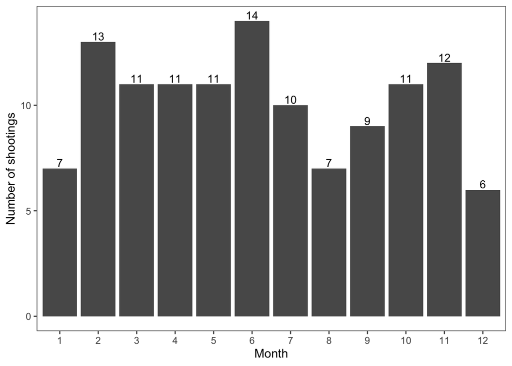

```r
mass_shootings %>%
  mutate(month = month(as.Date(mass_shootings$date, "%m/%d/%y"))) %>%
  filter(type == "Mass") %>%
  group_by(month) %>%
  summarise(shootings = n()) %>%
  ggplot(aes(x = as.factor(month), y = shootings)) +
  geom_bar(stat = "identity") +
  geom_text(aes(label = shootings), vjust = -0.2) +
  xlab("Month") +
  ylab("Number of shootings") +
  ggthemes::theme_few()
```

```r
# June has the most mass shootings
```

- How does the distribution of mass shooting fatalities differ between White and Black shooters? What about White and Latino shooters?

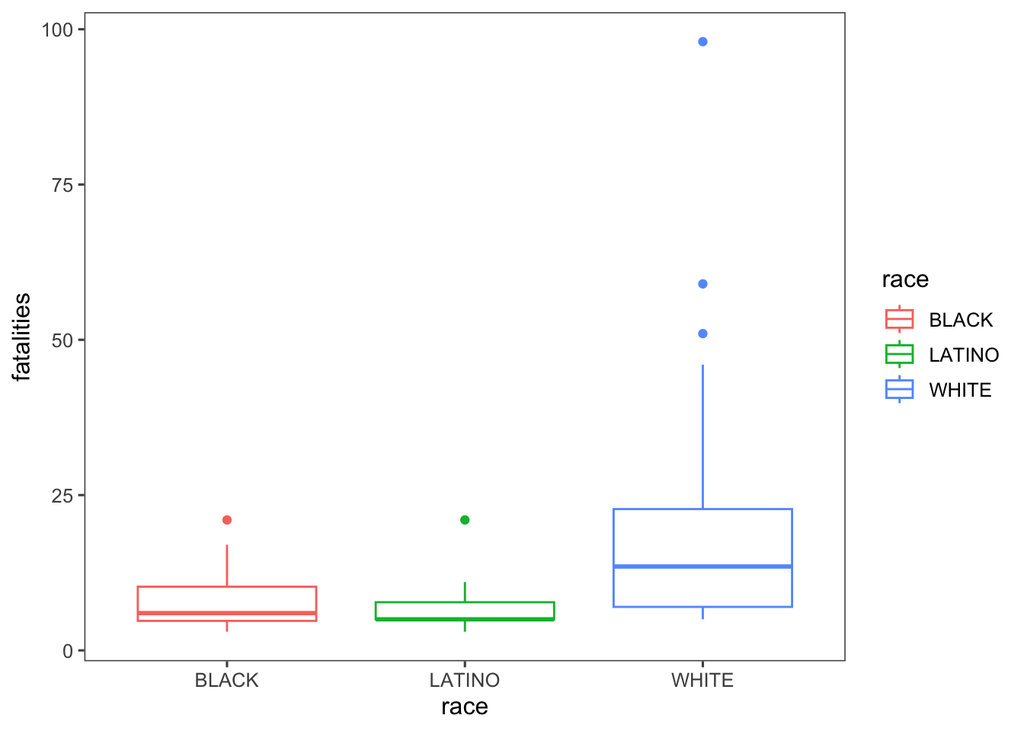

```r
mass_shootings %>%
  mutate(race = toupper(replace(race, race == "-","Other"))) %>%
  group_by(race,year) %>%
  summarise(fatalities = sum(fatalities), shootings = n()) %>%
  filter(race %in% c("BLACK","WHITE","LATINO")) %>%
  ggplot(aes(x = race, y = fatalities, color = race)) +
  geom_boxplot() +
  ggthemes::theme_few()
```

```r
# white shooters have a much higher amount of fatalities than black or latino shooters
```

### 2.2.3 Very open-ended

- Are mass shootings with shooters suffering from mental illness different from mass shootings with no signs of mental illness in the shooter?

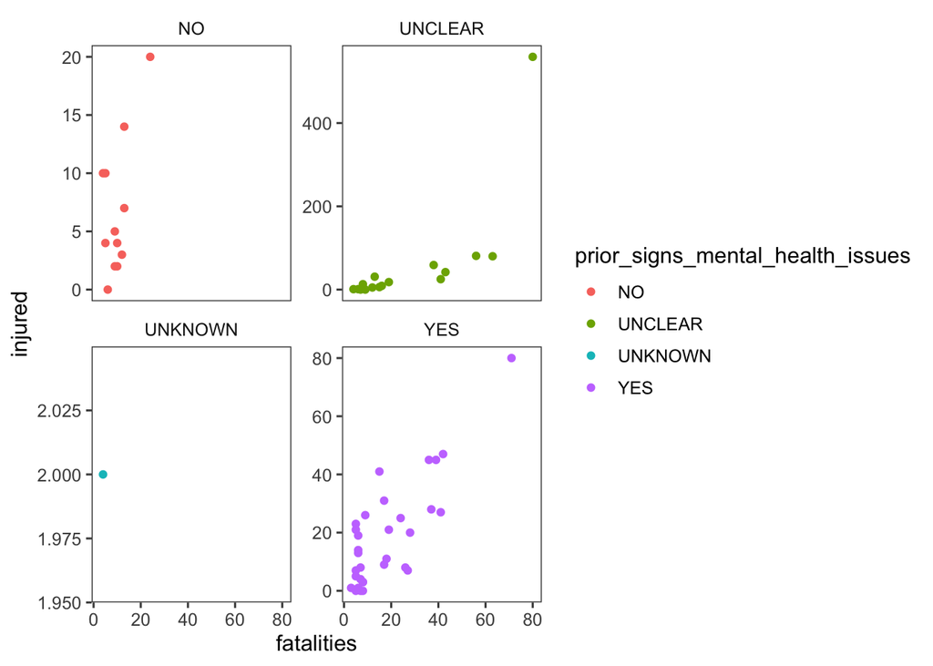

```r
mass_shootings %>%
  # clean up values
  mutate(race = toupper(replace(race, race == "-","Other")),
         prior_signs_mental_health_issues = toupper(replace(prior_signs_mental_health_issues,
                                                            prior_signs_mental_health_issues %in% c("-","TBD"),"Unclear"))) %>%
  group_by(prior_signs_mental_health_issues, year) %>%
  summarise(fatalities = sum(fatalities), injured = sum(injured), total_victims = sum(total_victims),count = n()) %>%
  ggplot(aes(x = fatalities, y = injured, color = prior_signs_mental_health_issues)) +
  geom_point() +
  facet_wrap(~prior_signs_mental_health_issues, scales = "free_y") +
  ggthemes::theme_few()
```

```r
# there are likely to be fewer fatalities when the shooter doesn't have any prior signs of mental issues
```

- Assess the relationship between mental illness and total victims, mental illness and location type, and the intersection of all three variables.

[figure not shown]

```r
mass_shootings %>%
  mutate_all(~gsub("\n","",.)) %>%
  mutate(race = toupper(replace(race, race == "-","Other")),
         prior_signs_mental_health_issues = toupper(replace(prior_signs_mental_health_issues,
                                                            prior_signs_mental_health_issues %in% c("-","TBD"),"Unclear"))) %>%
  group_by(mental_issues = prior_signs_mental_health_issues,
           location = toupper(location...8), year) %>%
  summarise(total_victims = sum(as.numeric(total_victims)),
            fatalities = sum(as.numeric(fatalities)),
            injured = sum(as.numeric(injured)), shootings = n()) %>%
  mutate(percent_fatal = fatalities / total_victims) %>%
  ggplot(aes(x = year, y = percent_fatal)) +
  geom_point(aes(size = total_victims, color = mental_issues)) +
  facet_wrap(~location) +
  ggthemes::theme_few()
```

```r
# Religious and military shootings are always related to mental issues (either known or unclear)
# Workplace shootings consistently have a high percent fatality rate across the years, regardless of mental issues
```

Make sure to provide a couple of sentences of written interpretation of your tables/figures. Graphs and tables alone will not be sufficient to answer this question.

# 3 Exploring credit card fraud

We will be using a dataset with credit card transactions containing legitimate and fraud transactions. Fraud is typically well below 1% of all transactions, so a naive model that predicts that all transactions are legitimate and not fraudulent would have an accuracy of well over 99%– pretty good, no? (well, not quite as we will see later in the course)

You can read more on credit card fraud on [Credit Card Fraud Detection Using Weighted Support Vector Machine](https://www.scirp.org/journal/paperinformation.aspx?paperid=105944)

The dataset we will use consists of credit card transactions and it includes information about each transaction including customer details, the merchant and category of purchase, and whether or not the transaction was a fraud.

## 3.1 Obtain the data

The dataset is too large to be hosted on Canvas or Github, so please download it from dropbox https://www.dropbox.com/sh/q1yk8mmnbbrzavl/AAAxzRtIhag9Nc_hODafGV2ka?dl=0 and save it in your `dsb` repo, under the `data` folder

```
## Rows: 671,028
## Columns: 14
## $ trans_date_trans_time <dttm> 2019-02-22 07:32:58, 2019-02-16 15:07:20, 2019-…
## $ trans_year            <dbl> 2019, 2019, 2019, 2019, 2019, 2019, 2019, 2020, …
## $ category              <chr> "entertainment", "kids_pets", "personal_care", "…
## $ amt                   <dbl> 7.79, 3.89, 8.43, 40.00, 54.04, 95.61, 64.95, 3.…
## $ city                  <chr> "Veedersburg", "Holloway", "Arnold", "Apison", "…
## $ state                 <chr> "IN", "OH", "MO", "TN", "CO", "GA", "MN", "AL", …
## $ lat                   <dbl> 40.1186, 40.0113, 38.4305, 35.0149, 39.4584, 32.…
## $ long                  <dbl> -87.2602, -80.9701, -90.3870, -85.0164, -106.385…
## $ city_pop              <dbl> 4049, 128, 35439, 3730, 277, 1841, 136, 190178, …
## $ job                   <chr> "Development worker, community", "Child psychoth…
## $ dob                   <date> 1959-10-19, 1946-04-03, 1985-03-31, 1991-01-28,…
## $ merch_lat             <dbl> 39.41679, 39.74585, 37.73078, 34.53277, 39.95244…
## $ merch_long            <dbl> -87.52619, -81.52477, -91.36875, -84.10676, -106…
## $ is_fraud              <dbl> 0, 0, 0, 0, 0, 0, 0, 0, 0, 0, 0, 0, 0, 0, 0, 0, …
```

The data dictionary is as follows

| column(variable) | description |
| --- | --- |
| trans_date_trans_time | Transaction DateTime |
| trans_year | Transaction year |
| category | category of merchant |
| amt | amount of transaction |
| city | City of card holder |
| state | State of card holder |
| lat | Latitude location of purchase |
| long | Longitude location of purchase |
| city_pop | card holder’s city population |
| job | job of card holder |
| dob | date of birth of card holder |
| merch_lat | Latitude Location of Merchant |
| merch_long | Longitude Location of Merchant |
| is_fraud | Whether Transaction is Fraud (1) or Not (0) |

- In this dataset, how likely are fraudulent transactions? Generate a table that summarizes the number and frequency of fraudulent transactions per year.
- How much money (in US$ terms) are fraudulent transactions costing the company? Generate a table that summarizes the total amount of legitimate and fraudulent transactions per year and calculate the % of fraudulent transactions, in US$ terms.
- Generate a histogram that shows the distribution of amounts charged to credit card, both for legitimate and fraudulent accounts. Also, for both types of transactions, calculate some quick summary statistics.
- What types of purchases are most likely to be instances of fraud? Consider category of merchants and produce a bar chart that shows % of total fraudulent transactions sorted in order.
- When is fraud more prevalent? Which days, months, hours? To create new variables to help you in your analysis, we use the `lubridate` package and the following code

```
mutate(
  date_only = lubridate::date(trans_date_trans_time),
  month_name = lubridate::month(trans_date_trans_time, label=TRUE),
  hour = lubridate::hour(trans_date_trans_time),
  weekday = lubridate::wday(trans_date_trans_time, label = TRUE)
  )
```

- Are older customers significantly more likely to be victims of credit card fraud? To calculate a customer’s age, we use the `lubridate` package and the following code

```
  mutate(
   age = interval(dob, trans_date_trans_time) / years(1),
    )
```

- Is fraud related to distance? The distance between a card holder’s home and the location of the transaction can be a feature that is related to fraud. To calculate distance, we need the latidue/longitude of card holders’s home and the latitude/longitude of the transaction, and we will use the [Haversine formula](https://en.wikipedia.org/wiki/Haversine_formula) to calculate distance. I adapted code to [calculate distance between two points on earth](https://www.geeksforgeeks.org/program-distance-two-points-earth/amp/) which you can find below

```r
# distance between card holder's home and transaction
# code adapted from https://www.geeksforgeeks.org/program-distance-two-points-earth/amp/


card_fraud <- card_fraud %>%
  mutate(

    # convert latitude/longitude to radians
    lat1_radians = lat / 57.29577951,
    lat2_radians = merch_lat / 57.29577951,
    long1_radians = long / 57.29577951,
    long2_radians = merch_long / 57.29577951,

    # calculate distance in miles
    distance_miles = 3963.0 * acos((sin(lat1_radians) * sin(lat2_radians)) + cos(lat1_radians) * cos(lat2_radians) * cos(long2_radians - long1_radians)),

    # calculate distance in km
    distance_km = 6377.830272 * acos((sin(lat1_radians) * sin(lat2_radians)) + cos(lat1_radians) * cos(lat2_radians) * cos(long2_radians - long1_radians))

  )
```

Plot a boxplot or a violin plot that looks at the relationship of distance and `is_fraud`. Does distance seem to be a useful feature in explaining fraud?

# 4 Exploring sources of electricity production, CO2 emissions, and GDP per capita.

There are many sources of data on how countries generate their electricity and their CO2 emissions. I would like you to create three graphs:

## 4.1 1. A stacked area chart that shows how your own country generated its electricity since 2000.

You will use

`geom_area(colour="grey90", alpha = 0.5, position = "fill")`

## 4.2 2. A scatter plot that looks at how CO2 per capita and GDP per capita are related

## 4.3 3. A scatter plot that looks at how electricity usage (kWh) per capita/day GDP per capita are related

We will get energy data from the Our World in Data website, and CO2 and GDP per capita emissions from the World Bank, using the `wbstats`package.

```r
# Download electricity data
url <- "https://nyc3.digitaloceanspaces.com/owid-public/data/energy/owid-energy-data.csv"

energy <- read_csv(url) %>%
  filter(year >= 1990) %>%
  drop_na(iso_code) %>%
  select(1:3,
         biofuel = biofuel_electricity,
         coal = coal_electricity,
         gas = gas_electricity,
         hydro = hydro_electricity,
         nuclear = nuclear_electricity,
         oil = oil_electricity,
         other_renewable = other_renewable_exc_biofuel_electricity,
         solar = solar_electricity,
         wind = wind_electricity,
         electricity_demand,
         electricity_generation,
         net_elec_imports,  # Net electricity imports, measured in terawatt-hours
         energy_per_capita, # Primary energy consumption per capita, measured in kilowatt-hours Calculated by Our World in Data based on BP Statistical Review of World Energy and EIA International Energy Data
         energy_per_gdp,    # Energy consumption per unit of GDP. This is measured in kilowatt-hours per 2011 international-$.
         per_capita_electricity, #  Electricity generation per capita, measured in kilowatt-hours
  )

# Download data for C02 emissions per capita https://data.worldbank.org/indicator/EN.ATM.CO2E.PC
co2_percap <- wb_data(country = "countries_only",
                      indicator = "EN.ATM.CO2E.PC",
                      start_date = 1990,
                      end_date = 2022,
                      return_wide=FALSE) %>%
  filter(!is.na(value)) %>%
  #drop unwanted variables
  select(-c(unit, obs_status, footnote, last_updated)) %>%
  rename(year = date,
         co2percap = value)


# Download data for GDP per capita  https://data.worldbank.org/indicator/NY.GDP.PCAP.PP.KD
gdp_percap <- wb_data(country = "countries_only",
                      indicator = "NY.GDP.PCAP.PP.KD",
                      start_date = 1990,
                      end_date = 2022,
                      return_wide=FALSE) %>%
  filter(!is.na(value)) %>%
  #drop unwanted variables
  select(-c(unit, obs_status, footnote, last_updated)) %>%
  rename(year = date,
         GDPpercap = value)
```

Specific questions:

1. How would you turn `energy` to long, tidy format?
2. You may need to join these data frames
   - Use `left_join` from `dplyr` to [join the tables](http://r4ds.had.co.nz/relational-data.html)
   - To complete the merge, you need a unique *key* to match observations between the data frames. Country names may not be consistent among the three dataframes, so please use the 3-digit ISO code for each country
   - An aside: There is a great package called [`countrycode`](https://github.com/vincentarelbundock/countrycode) that helps solve the problem of inconsistent country names (Is it UK? United Kingdom? Great Britain?). `countrycode()` takes as an input a country’s name in a specific format and outputs it using whatever format you specify.
3. Write a function that takes as input any country’s name and returns all three graphs. You can use the `patchwork` package to arrange the three graphs as shown below

[figure not shown]

# 5 Deliverables

There is a lot of explanatory text, comments, etc. You do not need these, so delete them and produce a stand-alone document that you could share with someone. Knit the edited and completed R Markdown (qmd) file as a Word or HTML document (use the “Knit” button at the top of the script editor window) and upload it to Canvas. You must be comitting and pushing your changes to your own Github repo as you go along.

# 6 Details

**Please seek out help when you need it,** and remember the [15-minute rule](https://dsb2023.netlify.app/syllabus/#the-15-minute-rule). You know enough R (and have enough examples of code from class and your readings) to be able to do this. If you get stuck, ask for help from others, post a question on Slack– and remember that I am here to help too!

> As a true test to yourself, do you understand the code you submitted and are you able to explain it to someone else?

# 7 Rubric

13/13: Problem set is 100% completed. Every question was attempted and answered, and most answers are correct. Code is well-documented (both self-documented and with additional comments as necessary). Used tidyverse, instead of base R. Graphs and tables are properly labelled. Analysis is clear and easy to follow, either because graphs are labeled clearly or you’ve written additional text to describe how you interpret the output. Multiple Github commits. Work is exceptional. I will not assign these often.

8/13: Problem set is 60–80% complete and most answers are correct. This is the expected level of performance. Solid effort. Hits all the elements. No clear mistakes. Easy to follow (both the code and the output). A few Github commits.

5/13: Problem set is less than 60% complete and/or most answers are incorrect. This indicates that you need to improve next time. I will hopefully not assign these often. Displays minimal effort. Doesn’t complete all components. Code is poorly written and not documented. Uses the same type of plot for each graph, or doesn’t use plots appropriate for the variables being analyzed. No Github commits.